# TCGA Data Analysis

# Load required library

```r
library(data.table)
library(R.utils)
library(ICeDT)
library(ggcorrplot)
```

Read CIBERSORT cell fraction estimates. The output could be txt or csv format. Here we just double check that the results are the same from the two formats.

```r
CBST_folder = "./CIBERSORT/CIBERSORTx_output"

cb_LM22    = read.csv(file.path(CBST_folder,"CIBERSORTx_LM22_Results.csv"))
cb_LM22_v2 = read.table(file.path(CBST_folder,"CIBERSORTx_LM22_Adjusted.txt"),
                        header=TRUE, as.is=TRUE)
cb_SF2018  = read.csv(file.path(CBST_folder,"CIBERSORTx_SF2018_Results.csv"))
cb_SF2018_filtered = read.csv(file.path(CBST_folder,
                     "CIBERSORTx_SF2018_filtered_cells_Results.csv"))
dim(cb_LM22)
```

```
## [1] 472  26
```

```r
cb_LM22[1:2,c(1:2,23:26)]
```

|  | Mixture | B.cells.naive | Neutrophils | P.value | Correlation | RMSE |
| --- | --- | --- | --- | --- | --- | --- |
| 1 | TCGA.D3.A8GB.06A | 0.067447854 | 8.560123e-06 | 0 | 0.5379340 | 0.8460075 |
| 2 | TCGA.WE.A8ZN.06A | 0.006532623 | 0.000000e+00 | 0 | 0.7292759 | 0.7352293 |

```r
dim(cb_LM22_v2)
```

```
## [1] 472  26
```

```r
cb_LM22_v2[1:2,c(1:2,23:26)]
```

|  | Mixture | B.cells.naive | Neutrophils | P.value | Correlation | RMSE |
| --- | --- | --- | --- | --- | --- | --- |
| 1 | TCGA.D3.A8GB.06A | 0.067447854 | 8.560123e-06 | 0 | 0.5379340 | 0.8460075 |
| 2 | TCGA.WE.A8ZN.06A | 0.006532623 | 0.000000e+00 | 0 | 0.7292759 | 0.7352293 |

```r
summary(c(data.matrix(cb_LM22[,-1])) - c(data.matrix(cb_LM22_v2[,-1])))
```

```
##    Min. 1st Qu.  Median    Mean 3rd Qu.    Max.
##       0       0       0       0       0       0
```

```r
dim(cb_SF2018)
```

```
## [1] 472  15
```

```r
cb_SF2018_filtered[1:2,c(1:2,12:15)]
```

|  | Mixture | B_cells | Tregs | P.value | Correlation | RMSE |
| --- | --- | --- | --- | --- | --- | --- |
| 1 | TCGA.D3.A8GB.06A | 0.0622155 | 0.09391737 | 0 | 0.4407617 | 0.9003162 |
| 2 | TCGA.WE.A8ZN.06A | 0.0000000 | 0.07311391 | 0 | 0.3452595 | 0.9494500 |

```r
dim(cb_SF2018)
```

```
## [1] 472  15
```

```r
cb_SF2018[1:2,c(1:2,12:15)]
```

|  | Mixture | B_cells | Tregs | P.value | Correlation | RMSE |
| --- | --- | --- | --- | --- | --- | --- |
| 1 | TCGA.D3.A8GB.06A | 0.01168705 | 0.01141962 | 0 | 0.2946370 | 0.9864763 |
| 2 | TCGA.WE.A8ZN.06A | 0.00000000 | 0.00000000 | 0 | 0.2863152 | 1.0036997 |

```r
summary(cb_LM22$Correlation)
```

```
##    Min. 1st Qu.  Median    Mean 3rd Qu.    Max.
## 0.04305 0.39464 0.52841 0.51838 0.64473 0.88339
```

```r
summary(cb_SF2018$Correlation)
```

```
##    Min. 1st Qu.  Median    Mean 3rd Qu.    Max.
## 0.02738 0.26671 0.32687 0.32477 0.38604 0.60803
```

```r
summary(cb_SF2018_filtered$Correlation)
```

```
##    Min. 1st Qu.  Median    Mean 3rd Qu.    Max.
## 0.04606 0.32830 0.40401 0.39242 0.46318 0.62794
```

Boxplot of cell fraction for each cell type inferred using LM22 signature matrix in CIBERSORTx

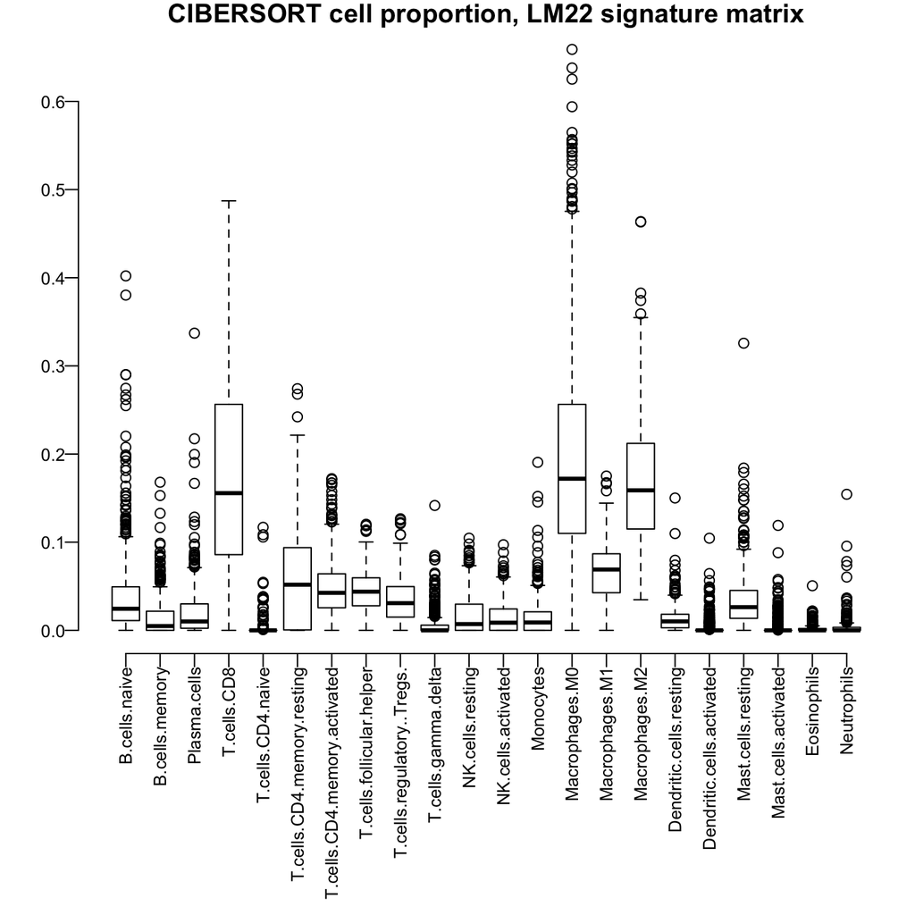

```r
par(mar=c(10,3,1,0.8), mgp=c(1.5,0.5,0), cex.axis=0.8, bty="n")
boxplot(cb_LM22[,2:23],las=2,
        main="CIBERSORT cell proportion, LM22 signature matrix")
```

Boxplot of cell fraction for each cell type inferred using SF2018 signature matrix in CIBERSORTx

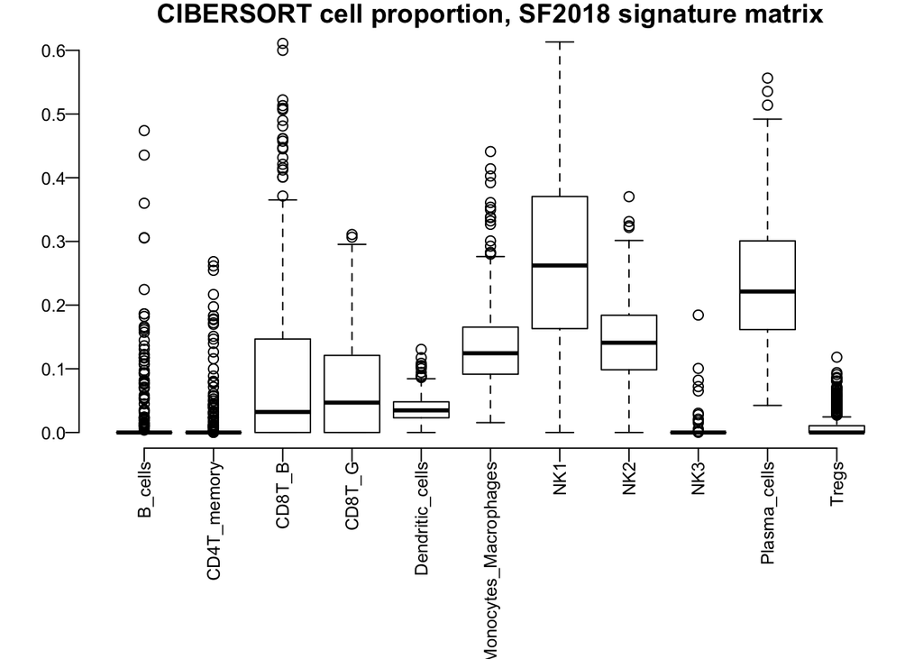

```r
par(mar=c(8,3,1,0.8), mgp=c(1.5,0.5,0), cex.axis=0.8, bty="n")
boxplot(cb_SF2018[,2:12], las=2,
        main="CIBERSORT cell proportion, SF2018 signature matrix")
```

Boxplot of cell fraction for each cell type inferred using SF2018_filtered_cells signature matrix in CIBERSORTx. Here filterd cells means using 200 cells with highest proportion of expressed genes per cell type.

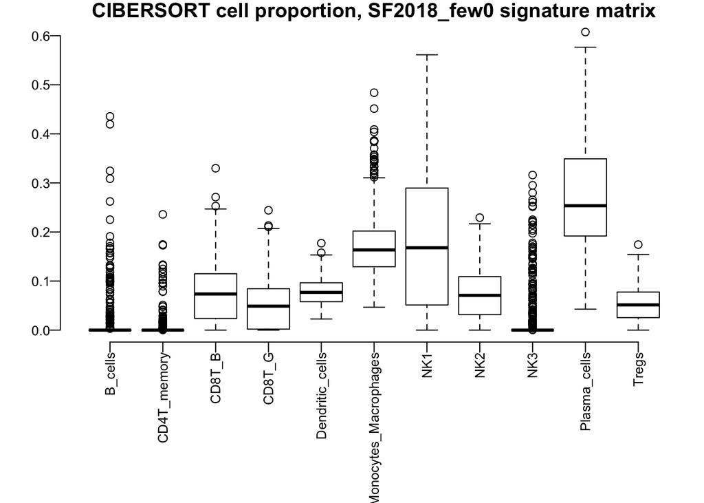

```r
par(mar=c(8,3,1,0.8), mgp=c(1.5,0.5,0), cex.axis=0.8, bty="n")
boxplot(cb_SF2018_filtered[,2:12], las=2,
        main="CIBERSORT cell proportion, SF2018_few0 signature matrix")
```

Correlation plot compare cell fractions inferred using LM22 signature matrix and SF2018 signature matrix in CIBERSORTx  
- For most of the cell types, we see the fractions inferred using different signature matrix correlated - Fractions of dendritic cell inferred using the 2 types of signature matrices have small correlation - The fractions three types of NK cells also showed some dubious correlation: such as correlation between NK1 and Macrophages.M0.

```r
table(cb_LM22$Mixture == cb_SF2018$Mixture)
```

```
##
## TRUE
##  472
```

```r
cb_LM22_mtrx   = data.matrix(cb_LM22[,2:23])
cb_SF2018_mtrx = data.matrix(cb_SF2018[,2:12])
cb_SF2018_filtered_mtrx = data.matrix(cb_SF2018_filtered[,2:12])

cormat_LM22_SF2018 = cor(cb_LM22_mtrx, cb_SF2018_mtrx,
                         method = "spearman")
cormat_LM22_SF2018_filtered = cor(cb_LM22_mtrx,
                                  cb_SF2018_filtered_mtrx,
                         method = "spearman")

summary(c(cormat_LM22_SF2018))
```

```
##      Min.   1st Qu.    Median      Mean   3rd Qu.      Max.
## -0.622789 -0.121628 -0.015125 -0.001872  0.111839  0.784402
```

```r
summary(c(cormat_LM22_SF2018_filtered))
```

```
##      Min.   1st Qu.    Median      Mean   3rd Qu.      Max.
## -0.619241 -0.129740 -0.008582 -0.002737  0.116529  0.571739
```

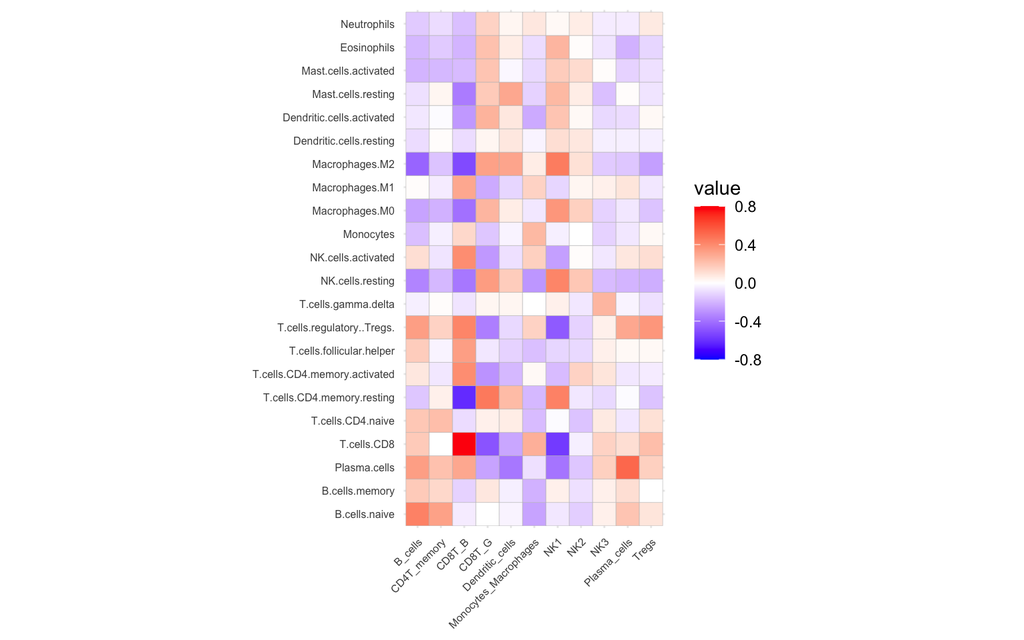

```r
ggcorrplot(t(cormat_LM22_SF2018), tl.cex = 6) +
  scale_fill_gradient2(limit = c(-0.8, 0.8), low = "blue",
                       high =  "red", mid = "white")
```

```r
round(cormat_LM22_SF2018,2)
```

```
##                              B_cells CD4T_memory CD8T_B CD8T_G Dendritic_cells
## B.cells.naive                   0.43        0.32  -0.05   0.00           -0.03
## B.cells.memory                  0.18        0.13  -0.12   0.08           -0.04
## Plasma.cells                    0.33        0.21   0.30  -0.25           -0.38
## T.cells.CD8                     0.18        0.00   0.78  -0.49           -0.24
## T.cells.CD4.naive               0.19        0.22  -0.09   0.05            0.06
## T.cells.CD4.memory.resting     -0.15        0.05  -0.62   0.46            0.23
## T.cells.CD4.memory.activated    0.08       -0.06   0.39  -0.30           -0.19
## T.cells.follicular.helper       0.17       -0.03   0.33  -0.06           -0.12
## T.cells.regulatory..Tregs.      0.33        0.15   0.42  -0.36           -0.10
## T.cells.gamma.delta            -0.04        0.01  -0.07   0.03            0.03
## NK.cells.resting               -0.34       -0.19  -0.38   0.34            0.17
## NK.cells.activated              0.11       -0.07   0.39  -0.28           -0.08
## Monocytes                      -0.17       -0.04   0.13  -0.15           -0.03
## Macrophages.M0                 -0.25       -0.21  -0.40   0.25            0.06
## Macrophages.M1                  0.01       -0.05   0.30  -0.23           -0.11
## Macrophages.M2                 -0.44       -0.16  -0.52   0.32            0.31
## Dendritic.cells.resting        -0.09        0.01  -0.09   0.03            0.08
## Dendritic.cells.activated      -0.06       -0.01  -0.28   0.26            0.08
## Mast.cells.resting             -0.08        0.03  -0.37   0.18            0.30
## Mast.cells.activated           -0.20       -0.19  -0.18   0.20           -0.02
## Eosinophils                    -0.19       -0.14  -0.20   0.21            0.06
## Neutrophils                    -0.14       -0.09  -0.17   0.15            0.03
##                              Monocytes_Macrophages   NK1   NK2   NK3
## B.cells.naive                                -0.25 -0.06 -0.13  0.05
## B.cells.memory                               -0.21  0.05 -0.08  0.05
## Plasma.cells                                 -0.08 -0.39 -0.15  0.16
## T.cells.CD8                                   0.27 -0.57 -0.04  0.15
## T.cells.CD4.naive                            -0.18 -0.01 -0.16  0.07
## T.cells.CD4.memory.resting                   -0.19  0.43 -0.06 -0.10
## T.cells.CD4.memory.activated                  0.02 -0.18  0.15  0.09
## T.cells.follicular.helper                    -0.17 -0.11 -0.10  0.05
## T.cells.regulatory..Tregs.                    0.15 -0.47 -0.12  0.05
## T.cells.gamma.delta                           0.00  0.05 -0.06  0.25
## NK.cells.resting                             -0.29  0.42  0.19 -0.18
## NK.cells.activated                            0.16 -0.26  0.01 -0.06
## Monocytes                                     0.24 -0.04  0.00 -0.12
## Macrophages.M0                               -0.06  0.36  0.16 -0.12
## Macrophages.M1                                0.15 -0.11  0.03  0.05
## Macrophages.M2                                0.06  0.45  0.10 -0.14
```

[output cut: 14 more lines]

```
## T.cells.follicular.helper            0.02  0.02
## T.cells.regulatory..Tregs.           0.30  0.36
## T.cells.gamma.delta                 -0.03 -0.08
## NK.cells.resting                    -0.20 -0.22
## NK.cells.activated                   0.08  0.11
## Monocytes                           -0.06  0.02
## Macrophages.M0                      -0.06 -0.16
## Macrophages.M1                       0.09 -0.06
## Macrophages.M2                      -0.15 -0.26
## Dendritic.cells.resting             -0.04 -0.04
## Dendritic.cells.activated           -0.09  0.02
## Mast.cells.resting                   0.01 -0.07
## Mast.cells.activated                -0.12 -0.08
## Eosinophils                         -0.21 -0.11
## Neutrophils                         -0.05  0.07
```

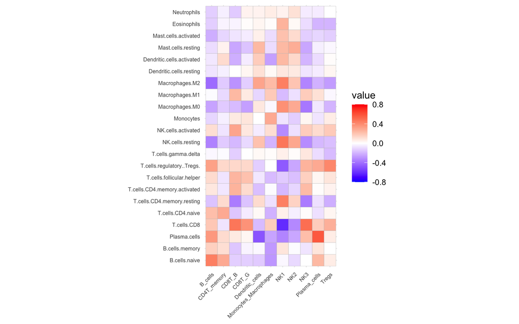

```r
ggcorrplot(t(cormat_LM22_SF2018_filtered), tl.cex = 6) +
    scale_fill_gradient2(limit = c(-0.8, 0.8), low = "blue",
                       high =  "red", mid = "white")
```

```r
round(cormat_LM22_SF2018_filtered,2)
```

```
##                              B_cells CD4T_memory CD8T_B CD8T_G Dendritic_cells
## B.cells.naive                   0.44        0.29  -0.13  -0.13           -0.14
## B.cells.memory                  0.16        0.11  -0.15  -0.03           -0.02
## Plasma.cells                    0.35        0.12   0.07   0.03           -0.49
## T.cells.CD8                     0.19       -0.07   0.47   0.37           -0.18
## T.cells.CD4.naive               0.22        0.29  -0.15  -0.05            0.02
## T.cells.CD4.memory.resting     -0.16        0.12  -0.37  -0.16            0.12
## T.cells.CD4.memory.activated    0.08       -0.06   0.26   0.12           -0.17
## T.cells.follicular.helper       0.12       -0.07   0.25   0.21           -0.06
## T.cells.regulatory..Tregs.      0.32        0.13   0.13   0.13           -0.13
## T.cells.gamma.delta            -0.02       -0.01  -0.13   0.00            0.02
## NK.cells.resting               -0.35       -0.14  -0.19  -0.10            0.21
## NK.cells.activated              0.11       -0.07   0.31   0.08           -0.05
## Monocytes                      -0.11       -0.04   0.07   0.09            0.00
## Macrophages.M0                 -0.25       -0.14  -0.18  -0.26            0.08
## Macrophages.M1                 -0.01       -0.10   0.24   0.07           -0.11
## Macrophages.M2                 -0.42       -0.14  -0.30  -0.13            0.31
## Dendritic.cells.resting        -0.07       -0.04   0.00   0.03            0.10
## Dendritic.cells.activated      -0.06        0.12  -0.22  -0.05            0.17
## Mast.cells.resting             -0.09        0.04  -0.24  -0.16            0.24
## Mast.cells.activated           -0.22       -0.11  -0.07  -0.05            0.05
## Eosinophils                    -0.13       -0.03  -0.03   0.01            0.03
## Neutrophils                    -0.13       -0.04  -0.14   0.04            0.04
##                              Monocytes_Macrophages   NK1   NK2   NK3
## B.cells.naive                                -0.29 -0.02 -0.10  0.00
## B.cells.memory                               -0.28  0.09 -0.01 -0.07
## Plasma.cells                                 -0.25 -0.34 -0.24  0.22
## T.cells.CD8                                   0.17 -0.62 -0.33  0.50
## T.cells.CD4.naive                            -0.21  0.05 -0.04  0.01
## T.cells.CD4.memory.resting                   -0.08  0.44  0.15 -0.37
## T.cells.CD4.memory.activated                 -0.01 -0.19 -0.11  0.23
## T.cells.follicular.helper                    -0.18 -0.14 -0.17  0.16
## T.cells.regulatory..Tregs.                    0.00 -0.47 -0.24  0.26
## T.cells.gamma.delta                           0.01  0.05  0.01  0.08
## NK.cells.resting                             -0.20  0.47  0.30 -0.32
## NK.cells.activated                            0.11 -0.32 -0.08  0.17
## Monocytes                                     0.29 -0.07 -0.13  0.03
## Macrophages.M0                               -0.02  0.38  0.29 -0.38
## Macrophages.M1                                0.18 -0.18 -0.08  0.17
## Macrophages.M2                                0.23  0.44  0.20 -0.34
```

[output cut: 14 more lines]

```
## T.cells.follicular.helper            0.03  0.09
## T.cells.regulatory..Tregs.           0.29  0.41
## T.cells.gamma.delta                 -0.09 -0.18
## NK.cells.resting                    -0.19 -0.17
## NK.cells.activated                   0.12  0.18
## Monocytes                           -0.07  0.06
## Macrophages.M0                      -0.06 -0.20
## Macrophages.M1                       0.10 -0.02
## Macrophages.M2                      -0.21 -0.27
## Dendritic.cells.resting             -0.05  0.03
## Dendritic.cells.activated           -0.09  0.01
## Mast.cells.resting                  -0.04 -0.02
## Mast.cells.activated                -0.11 -0.13
## Eosinophils                         -0.20 -0.20
## Neutrophils                         -0.05  0.00
```

Correlation plot compare cell fractions inferred using SF2018 signature matrix and SF2018_filtered signature matrix in CIBERSORTx  
- We saw positive correlation for the fraction of the same cell type inferred by the 2 different signature matrix.

```r
cormat_SF2018 = cor(cb_SF2018_mtrx, cb_SF2018_filtered_mtrx,
                         method = "spearman")

summary(c(cormat_SF2018))
```

```
##     Min.  1st Qu.   Median     Mean  3rd Qu.     Max.
## -0.71256 -0.19495  0.01046  0.02219  0.18254  0.93162
```

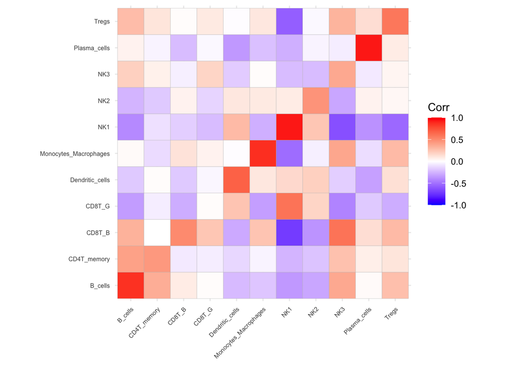

```r
ggcorrplot(t(cormat_SF2018), tl.cex = 6)
```

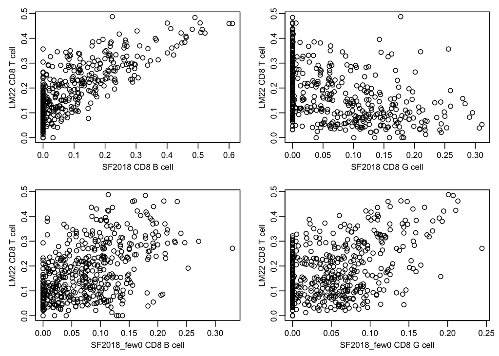

```r
par(mar=c(3,3,1,0.8), mgp=c(1.5,0.5,0), cex.axis=0.85, cex.lab=0.85, cex.main=0.85)
layout(matrix(c(1,2,3,4),nrow=2,ncol = 2,byrow = TRUE))

plot(cb_SF2018$CD8T_B, cb_LM22$T.cells.CD8,
     xlab = "SF2018 CD8 B cell", ylab = "LM22 CD8 T cell")

plot(cb_SF2018$CD8T_G, cb_LM22$T.cells.CD8,
     xlab = "SF2018 CD8 G cell", ylab = "LM22 CD8 T cell")

plot(cb_SF2018_filtered$CD8T_B, cb_LM22$T.cells.CD8,
     xlab = "SF2018_few0 CD8 B cell", ylab = "LM22 CD8 T cell")

plot(cb_SF2018_filtered$CD8T_G, cb_LM22$T.cells.CD8,
     xlab = "SF2018_few0 CD8 G cell", ylab = "LM22 CD8 T cell")
```

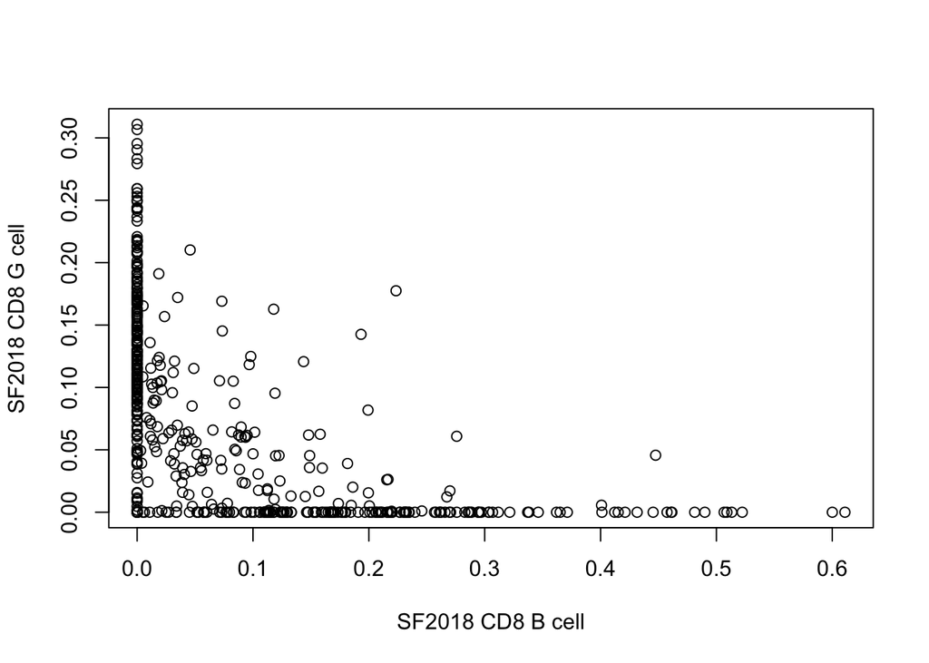

```r
plot(cb_SF2018$CD8T_B, cb_SF2018$CD8T_G,
     xlab = "SF2018 CD8 B cell", ylab = "SF2018 CD8 G cell")
```

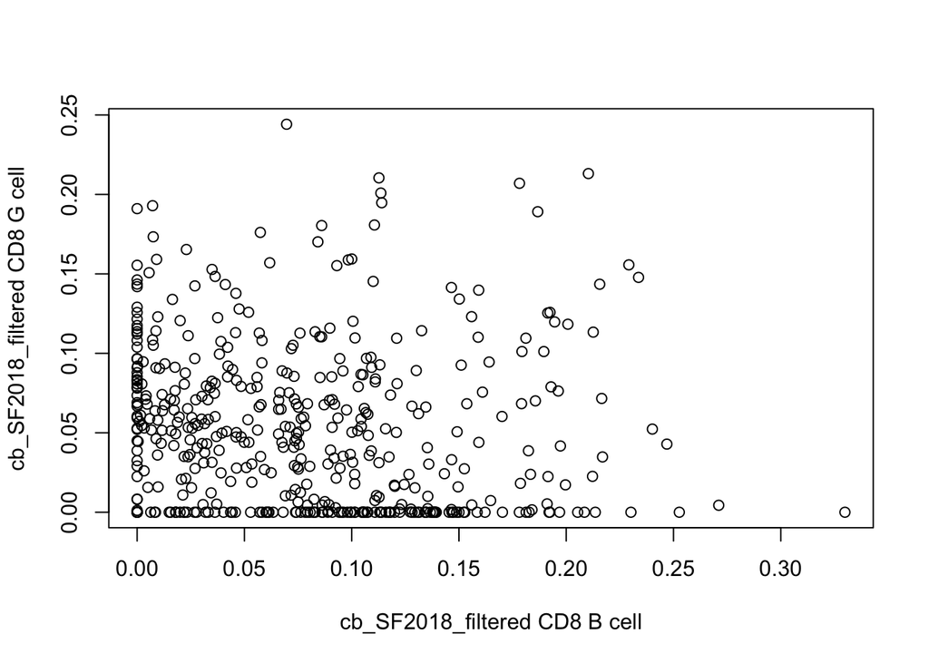

```r
plot(cb_SF2018_filtered$CD8T_B, cb_SF2018_filtered$CD8T_G,
     xlab = "cb_SF2018_filtered CD8 B cell",
     ylab = "cb_SF2018_filtered CD8 G cell")
```

```r
gc()
```

```
##           used (Mb) gc trigger (Mb) limit (Mb) max used (Mb)
## Ncells  903020 48.3    1801207 96.2         NA  1236944 66.1
## Vcells 1697063 13.0    8388608 64.0      32768  2804395 21.4
```